# Topic 13

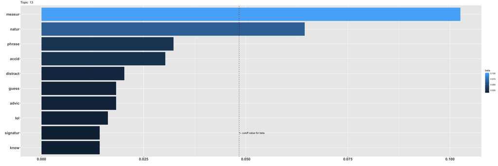

On interpreting beta: the term has a beta probability of being generated from the particular topic.

Values below are gamma : An estimated proportion of words from that document that are generated from that topic.

**Text Record Number: 618** gamma: 16 % likelihood of this document (based on its words) in this topic

**Hi! I have an undergrad in piano performance at uni and my advice would be to cut your practice in 20 minutes increments. I used to practice 6hrs a day, today it’s more 3-4 (can’t do 5, I tried lol) because of an injury and my progress has not slowed down. You get distracted because you’re human and humans aren’t necessarily made to be 100% focused for hours on end without breaks.

Have some practice outside the piano: analyze your music. Identifying patterns and the harmony helps with memorizing and understanding what you’re learning.

Plus, 10 measures a day doesn’t say much because it depends on the measures as you know. Why not make yourself some kind of schedule? Like put in a calendar which measures you learn and add those from the previous days. You’ll feel less stressed knowing in advance in how long you’ll learn your new piece. You won’t feel like x number of measures is too little because it’s all part of your schedule.

Add some variety to your practice by learning more stuff maybe? You’re used to Chopin who has his particular style, so why not give you some change and learn a piece in another style? I feel like sometimes my brain gets all fuzzy when I focus too much on one piece. So I take a break and come back to the piano to practice something else. I love Schubert, but playing Bartok after a little break will give me some welcomed change and a little burst of energy. Anyway you want to have skills in many styles.

All in all, I would not practice more because you already say you’re distracted and truly, 6 hours is way more than enough. It goes to show that maybe you have the discipline to stay at the instrument for 6hrs a day, but you can’t escape your human nature and something’s got to give. So you loose concentration and ultimately loose your own time. Organize your practice, get some variety in your practice (more music genres, scales, sight reading, analyzing, etc), take A LOT of breaks, get yourself a cup of tea and don’t be disappointed in yourself: you work hard, but maybe learn to work better. Maybe ask your teacher if they have some pointers on how they practice themselves? I thought I knew how to practice, but really, I wasn’t the most efficient and I know I still am not today. Like all things, it’s a process and give yourself a break, I’m sure you deserve it.**

**Text Record Number: 835** gamma: 16 % likelihood of this document (based on its words) in this topic

**It could also be a natural following a accidental in the same measure, right? For example, in the key of C, if there is a G# and then a G natural, the second one would have to have the natural sign, but would not be considered an accidental because it’s still in the key of C.**

**Text Record Number: 58** gamma: 16 % likelihood of this document (based on its words) in this topic

**I would say be your own teacher tbh, and do something similar to what my teacher does, which is assign “homework” every week.

In other words, have a list of goals for the following week.

I would say you should break each piece up into steps. My homework/goals for a 40 measure piece might look like the following:

Week 1: hands separate, first 20 measures

Week 2: hands together, first 20 measures

Week 3/4: repeat the same thing for the next 20 measures

Week 5: work on fluidity of piece

Week 6-8 (varies): work on phrasing and expression

It’s not a concrete guide but that’s generally how I tackle a piece.**

**Text Record Number: 1009** gamma: 16 % likelihood of this document (based on its words) in this topic

**I find this is pretty common in my experience and just one of the many stages of developing as a pianist, so first and foremost I’d say don’t be stressed out or concerned by this but it is definitely something you can improve on.

I dont have hard evidence for the psychology behind it but generally I’ve found that musicians hear what they want to hear when they’re playing - they’re focused on achieving a certain result and hear that result, but irrespective of this we are very unreliable in the way that we hear ourselves. This is perhaps what your teacher is driving at. If you’ve ever recorded yourself playing and listened back thinking “wow that was worse than I thought” then this is likely a similar situation.

How to solve this? Obvious answer : experience. But experience doing what? You need to do a couple of things IMO:

1. Record yourself loads. Listen to yourself, be critical of yourself but also listen for what you do well.
2. Play hands separately and sing the parts as you play, try to have your fingers mimic the phrasing of your singing. Do this on very small sections to begin with (one phrase at a time)
3. Play for other people. We become much more aware of our playing when we perform for other people (family, friends, strangers, anyone). This is largely because we start to concentrate in a way that we can’t often quite achieve when we’re practising to give the best performance we can. If you can learn to take this same mental state into your practice you’ll find yourself “listening” more to your own playing

I hope this helps!**

**Text Record Number: 176** gamma: 16 % likelihood of this document (based on its words) in this topic

**You’re doing an excellent job, really.

I think what you need to improve is all about phrasing.

Phrasing isn’t just about the dynamics within the phrase and associated (usually legato) articulation, but also what happens *between* phrases. Try *singing* the melody to yourself, honestly, and see where you breathe. You need to “breathe” in piano too, maybe with extremely small rubato-like ritardandos, or perhaps with a tiny bit of space between phrases. I feel like a lot of your phrases are dynamically static, and temporally running into each other like they’re just a big sequence of notes being played, as opposed to logical groups that have separate “meaning”.**

**Text Record Number: 602** gamma: 16 % likelihood of this document (based on its words) in this topic

**It’s natural to get distracted and most people would consider this a bad thing, getting in the way of your practice schedule. I’d say, accept that you will have distractions and re-name them so that they are now breaks. Your brain works well after distractions; focus on one thing for 10-20 mins and then build in a distraction of a few minutes. Your brain works to strengthen connections when you’ve ‘nearly forgotten’ something. You’re telling your brain “this is long-term memory learning, not short-term.” Focus on something different and once again, come back to it for just 2-5 minutes even. Also play it just before you go to sleep, again for 5 mins, and your brain will work to consolidate the information as you sleep. This is a brain-hack backed up by real science and it’s like a cheat code it’s so effective.**

**Text Record Number: 918** gamma: 16 % likelihood of this document (based on its words) in this topic

**in the same measure yes, in the next measure no. Accidentals only last for the measure they are written. Many times you’ll see them remind you next measure that its back to its normal key.**